# Movie Text Mining: Tokenization, Topic Modeling, Sentiment Analysis, Network of Bigrams

Marie Hasegawa

# Appendix

- Library of Packages
- Project Overview
  - Import IMDB_movies Data
- Tokenization Relationships in Movie Franchise
- Topic Modeling
- Sentimental Analysis of Movies with Clusters: How Sentiment affects Rating and Revenue
  - Sentiment Analysis of Movies using bing lexicon
  - Sentiment Analysis of Movies using nrc lexicon
- Network of Bigrams for Movies
- Conclusion
- References

# Library of Packages

```r
library(tidyverse)
library(tidytext)
library(topicmodels)
library(ggplot2)
#install.packages("viridis")
library(viridis)
#install.packages("textdata")
library(textdata)
#if(!require(psych)){install.packages("psych")}
#if(!require(cluster)){install.packages("cluster")}
#if(!require(fpc)){install.packages("fpc")}
library(psych)
library(cluster)
library(fpc)
#install.packages("ggraph")
#install.packages("igraph")
library(igraph)
library(ggraph)
#install.packages("topicmodels")
library(topicmodels)
#install.packages("reshape2")
library(reshape2)
```

# Project Overview

### Import IMDB_movies Data

Read the dataset for this exercise:

```r
movie_desc <- read_csv("https://raw.githubusercontent.com/reisanar/datasets/master/IMDB_movies.csv")
names(movie_desc)<-str_replace_all(names(movie_desc), c(" " = "." , "\\(" = "", "\\)" = ""))
movie_desc <-select(movie_desc, -c(Director, Genre, Actors, Year))
movie_desc
```

| Rank | Title | Description | Runtime.Minutes | Rating | Votes | Revenue.Millions | Metascore |
| --- | --- | --- | --- | --- | --- | --- | --- |
| 1 | Guardians of the Galaxy | A group of intergalactic criminals are forced to work together to stop a fanatical warrior from taking control of the universe. | 121 | 8.1 | 757074 | 333.13 | 76 |
| 2 | Prometheus | Following clues to the origin of mankind, a team finds a structure on a distant moon, but they soon realize they are not alone. | 124 | 7.0 | 485820 | 126.46 | 65 |
| 3 | Split | Three girls are kidnapped by a man with a diagnosed 23 distinct personalities. They must try to escape before the apparent emergence of a frightful new 24th. | 117 | 7.3 | 157606 | 138.12 | 62 |
| 4 | Sing | In a city of humanoid animals, a hustling theater impresario's attempt to save his theater with a singing competition becomes grander than he anticipates even as its finalists' find that their lives w… | 108 | 7.2 | 60545 | 270.32 | 59 |
| 5 | Suicide Squad | A secret government agency recruits some of the most dangerous incarcerated super-villains to form a defensive task force. Their first mission: save the world from the apocalypse. | 123 | 6.2 | 393727 | 325.02 | 40 |
| 6 | The Great Wall | European mercenaries searching for black powder become embroiled in the defense of the Great Wall of China against a horde of monstrous creatures. | 103 | 6.1 | 56036 | 45.13 | 42 |
| 7 | La La Land | A jazz pianist falls for an aspiring actress in Los Angeles. | 128 | 8.3 | 258682 | 151.06 | 93 |
| 8 | Mindhorn | A has-been actor best known for playing the title character in the 1980s detective series "Mindhorn" must work with the police when a serial killer says that he will only speak with Detective Mindhorn… | 89 | 6.4 | 2490 | NA | 71 |
| 9 | The Lost City of Z | A true-life drama, centering on British explorer Col. Percival Fawcett, who disappeared while searching for a mysterious city in the Amazon in the 1920s. | 141 | 7.1 | 7188 | 8.01 | 78 |
| 10 | Passengers | A spacecraft traveling to a distant colony planet and transporting thousands of people has a malfunction in its sleep chambers. As a result, two passengers are awakened 90 years early. | 116 | 7.0 | 192177 | 100.01 | 41 |

[output cut: 990 more lines]

```r
NA
```

The purpose of this project is to see if text mining techniques can ease better analysis for categorizing movies with just the `Descriptions` while ignoring the `Genre`from the dataset, `IMDB_movies.csv`, which is stored under the dataframe variable, `movies_desc`.

Tokenization (`TF-DF`) will be used to analyze term frequencies in movie `Descriptions` in order to determine the conceptual theme of a movie franchise.

Using Topic Modeling will help find mixtures of terms that are associated to every topic and the mixture of topics that characterizes every document in the dataset, `IMDB_movies.csv`.

Sentimental Analysis of movies with `Sentimetal` clusters which will be using `bing` and `nrc` lexicons to see how `Sentiment` affects `Ratings` and `Revenues`.

The movie network of bigrams help illustrate how frequented word-relations from film `Descriptions` connect with other movies.

# Tokenization Relationships in Movies Franchise

```r
movie_tf_idf <- movie_desc %>%
  unnest_tokens(word, Description) %>% # tokenization
  anti_join(stop_words) %>% #remove stop words
  count(Title, word, sort=TRUE) %>%
  bind_tf_idf(word, Title, n) %>%
  arrange(-tf_idf) %>%
  group_by(Title) %>%
  top_n(20) %>%
  ungroup
movie_tf_idf
```

| Title | word | n | tf | idf | tf_idf |
| --- | --- | --- | --- | --- | --- |
| Funny Games | psychopathic | 1 | 0.2500000 | 6.906755 | 1.7266887 |
| Good Kids | redefine | 1 | 0.2500000 | 6.906755 | 1.7266887 |
| Kickboxer: Vengeance | avenge | 1 | 0.2500000 | 6.906755 | 1.7266887 |
| Room | shed | 1 | 0.2500000 | 6.906755 | 1.7266887 |
| Kickboxer: Vengeance | kick | 1 | 0.2500000 | 6.213608 | 1.5534019 |
| Room | confines | 1 | 0.2500000 | 6.213608 | 1.5534019 |
| John Wick | hitman | 1 | 0.2500000 | 5.808142 | 1.4520356 |
| Diary of a Wimpy Kid: Dog Days | summer | 2 | 0.2857143 | 4.960845 | 1.4173842 |
| Bacalaureat | compromises | 1 | 0.2000000 | 6.906755 | 1.3813510 |
| Enemy | alike | 1 | 0.2000000 | 6.906755 | 1.3813510 |

[output cut: 990 more lines]

TF-IDF, **Term Frequency**, refers to the number of times a term (t) appears in a document (d). In terms of this project, the Term Frequency of movies in the dataset, `IMDB_movies.csv`, is the number of times a term (t) appears in the column, `Description`, from the dataframe, `movie_desc`. This section explores the conceptual patterns in movie franchises’ sequels with tokenization.

```r
text_plot <- movie_tf_idf %>%
  mutate(word = reorder(word, tf_idf)) %>%
  filter(str_detect(Title, c("Harry Potter"))) %>%
  ggplot(aes(x=word, y=tf_idf, fill=Title)) +
  geom_col(alpha=0.8, show.legend = FALSE) +
  facet_wrap(~ Title, scales = "free", ncol = 2) +
  coord_flip() +
  labs(x="", y="tf-idf", title="Highest tf-idf words in Harry Potter Movie Franchise data") +
  theme_minimal()
text_plot
```

[output not shown]

Using tokenization with a franchise’s movies’ `Description` allows easier understanding of the nature of a movie’s franchise without watching the actual films. This is especially useful for streaming services who can use tokenization to determine a movie’s general theme and atmosphere in order to better organize their films’ genres.

# Topic Modeling

```r
text_tidy<-movie_desc %>%
  unnest_tokens(word, Description) %>%
  anti_join(stop_words)
text_tidy
```

| Rank | Title | Runtime.Minutes | Rating | Votes | Revenue.Millions | Metascore | word |
| --- | --- | --- | --- | --- | --- | --- | --- |
| 1 | Guardians of the Galaxy | 121 | 8.1 | 757074 | 333.13 | 76 | intergalactic |
| 1 | Guardians of the Galaxy | 121 | 8.1 | 757074 | 333.13 | 76 | criminals |
| 1 | Guardians of the Galaxy | 121 | 8.1 | 757074 | 333.13 | 76 | forced |
| 1 | Guardians of the Galaxy | 121 | 8.1 | 757074 | 333.13 | 76 | stop |
| 1 | Guardians of the Galaxy | 121 | 8.1 | 757074 | 333.13 | 76 | fanatical |
| 1 | Guardians of the Galaxy | 121 | 8.1 | 757074 | 333.13 | 76 | warrior |
| 1 | Guardians of the Galaxy | 121 | 8.1 | 757074 | 333.13 | 76 | taking |
| 1 | Guardians of the Galaxy | 121 | 8.1 | 757074 | 333.13 | 76 | control |
| 1 | Guardians of the Galaxy | 121 | 8.1 | 757074 | 333.13 | 76 | universe |
| 2 | Prometheus | 124 | 7.0 | 485820 | 126.46 | 65 | clues |

[output cut: 990 more lines]

> The code above removes stop words for better efficiency in topic modeling.

```r
text_dtm <- text_tidy %>%
  count(Title, word, sort=TRUE) %>%
  cast_dtm(Title, word, n)
class(text_dtm)
```

```
[1] "DocumentTermMatrix"    "simple_triplet_matrix"
```

> The dataframe `text_dtm` has class types called `DocumentTermMatrix` and `simple_triplet_matrix`.

```r
text_lda<-LDA(text_dtm, k=4, control=list(seed=1234))
text_lda
```

```
A LDA_VEM topic model with 4 topics.
```

> The data frame, `text_dtm`, was modified to have 4 topics and a seed set to number `1234`.

**Latent Dirichlet Allocation** (LDA) will be used for Topic Modeling in this project, since it allows documents to overlap one another based in terms of content. LDA determines the mixture of terms that is associated to every topic, while it also finds the mixture of topics that characterize each document.

This section will use `LDA` and `Topic Modeling` to determine the most frequented terms for 4 topics by `beta` size regarding movies, and show the greatest difference among Movie topics.

```r
text_topics <- tidy(text_lda, matrix = "beta")
text_topics
```

| topic | term | beta |
| --- | --- | --- |
| 1 | peaks | 2.117416e-04 |
| 2 | peaks | 9.055543e-04 |
| 3 | peaks | 2.320694e-05 |
| 4 | peaks | 3.300401e-05 |
| 1 | twin | 3.496746e-04 |
| 2 | twin | 1.371579e-03 |
| 3 | twin | 1.211006e-05 |
| 4 | twin | 2.694687e-05 |
| 1 | spy | 1.478116e-03 |
| 2 | spy | 3.250996e-04 |

[output cut: 990 more lines]

> The data frame above is an extraction of `word-topic probabilities` (betas).

```r
top_terms <- text_topics %>%
  group_by(topic) %>%
  top_n(10, beta) %>%
  ungroup() %>%
  arrange(topic, -beta)

top_terms
```

| topic | term | beta |
| --- | --- | --- |
| 1 | life | 0.010060437 |
| 1 | family | 0.007300429 |
| 1 | love | 0.005809243 |
| 1 | city | 0.005285449 |
| 1 | school | 0.004721132 |
| 1 | home | 0.004465863 |
| 1 | agent | 0.004405568 |
| 1 | world | 0.003720395 |
| 1 | american | 0.003540172 |
| 1 | war | 0.003345046 |

[output cut: 30 more lines]

> Data frame of the top 10 most common terms within each topic.

```r
top_terms %>%
  mutate(topic = paste0("Topic ", topic),
         term = reorder(term, beta))
```

| topic | term | beta |
| --- | --- | --- |
| Topic 1 | life | 0.010060437 |
| Topic 1 | family | 0.007300429 |
| Topic 1 | love | 0.005809243 |
| Topic 1 | city | 0.005285449 |
| Topic 1 | school | 0.004721132 |
| Topic 1 | home | 0.004465863 |
| Topic 1 | agent | 0.004405568 |
| Topic 1 | world | 0.003720395 |
| Topic 1 | american | 0.003540172 |
| Topic 1 | war | 0.003345046 |

[output cut: 30 more lines]

> This is the same table as the one previously, but has the word `Topic` in front of the `Topic` number

```r
graph_topics <- top_terms %>%
  mutate(topic = paste0("Topic ", topic),
         term = reorder(term, beta)) %>%
  ggplot(aes(x = term, y = beta, fill = factor(topic))) +
  geom_col(alpha = 0.8, show.legend = FALSE) +
  facet_wrap(~topic, scales = "free_y") +
  coord_flip() +
  labs(x="", y=expression(beta))
  theme_minimal()
```

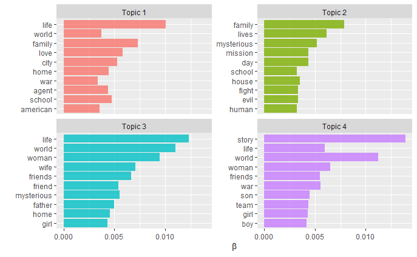

```r
graph_topics
ggsave("graph_topics.pdf", graph_topics,  width = 10, height = 4)
```

The dataframe above shows the top 10 most common terms within each topic. For `Topic 1`, the term, `life`, has the highest `beta` level of `0.010060437`, which suggests that the term, `life`, is the most common term in `Topic 1`. For `Topic 2`, the term, `family`, has the highest `beta` level of `0.007863619`, which suggests that the term, `family`, is the most common term in `Topic 2`. For `Topic 3`, the term, `life`, has the highest `beta` level of `0.012327667`, which suggests that the term, `life`, is the most common term in `Topic 3`. For `Topic 4`, the term, `story`, has the highest `beta` level of `0.013904911`, which suggests that the term, `story`, is the most common term in `Topic 4`.

[figure not shown]

```r
beta_spread <- text_topics %>%
  mutate(topic = paste0("topic", topic)) %>%
  spread(topic, beta) %>%
  filter(topic1 > .001 | topic4 > .001) %>%
  mutate(log_ratio = log2(topic3 / topic1))
beta_spread %>%
  group_by(direction = log_ratio > 0) %>%
  top_n(10, abs(log_ratio)) %>%
  ungroup() %>%
  mutate(term = reorder(term, log_ratio)) %>%
  ggplot(aes(x = term, y = log_ratio)) +
  geom_col() +
  labs(
    x = "",
    y = "Log2 ratio of beta in topic 4 / topic 1") +
  coord_flip() +
  theme_minimal()
```

# Sentimental Analysis of Movies with Clusters: How Sentiment affects Rating and Revenue

```r
#Remove Stop words
movie_stop_rem<-movie_desc %>%
  unnest_tokens(word, Description, token="words") %>%
  filter(!word %in% stop_words$word, str_detect(word, "[a-z]"))

movie_stop_rem
```

| Rank | Title | Runtime.Minutes | Rating | Votes | Revenue.Millions | Metascore | word |
| --- | --- | --- | --- | --- | --- | --- | --- |
| 1 | Guardians of the Galaxy | 121 | 8.1 | 757074 | 333.13 | 76 | intergalactic |
| 1 | Guardians of the Galaxy | 121 | 8.1 | 757074 | 333.13 | 76 | criminals |
| 1 | Guardians of the Galaxy | 121 | 8.1 | 757074 | 333.13 | 76 | forced |
| 1 | Guardians of the Galaxy | 121 | 8.1 | 757074 | 333.13 | 76 | stop |
| 1 | Guardians of the Galaxy | 121 | 8.1 | 757074 | 333.13 | 76 | fanatical |
| 1 | Guardians of the Galaxy | 121 | 8.1 | 757074 | 333.13 | 76 | warrior |
| 1 | Guardians of the Galaxy | 121 | 8.1 | 757074 | 333.13 | 76 | taking |
| 1 | Guardians of the Galaxy | 121 | 8.1 | 757074 | 333.13 | 76 | control |
| 1 | Guardians of the Galaxy | 121 | 8.1 | 757074 | 333.13 | 76 | universe |
| 2 | Prometheus | 124 | 7.0 | 485820 | 126.46 | 65 | clues |

[output cut: 990 more lines]

```r
#movie_stop_rem %>%
#  filter(word=="stop")
```

> The table above removed stop words for easier text mining in sentimental analysis, and list terms from each movie.

```r
# check some of the most frequent words
movie_freq_word<-movie_stop_rem %>%
  group_by(word) %>%
  summarise(uses=n()) %>%
  arrange(desc(uses)) %>%
  slice(1:15)
movie_freq_word
```

| word | uses |
| --- | --- |
| life | 106 |
| world | 90 |
| family | 61 |
| woman | 60 |
| story | 55 |
| love | 52 |
| friends | 51 |
| mysterious | 49 |
| home | 47 |
| girl | 44 |

[output cut: 5 more lines]

> List the most frequently used words in the Movie `Description`

Section `Sentimental Analysis of Movies with Clusters` will use both `bing` and `nrc` lexicons to see how `Sentiment` affects `Rating` and `Revenue`. According to the article, [Sentiment analysis with tidy data](https://www.tidytextmining.com/sentiment.html), both lexicons have less positive words than negative words, yet “the ratio of negative to positive words is higher in the `bing` lexicon than the `nrc` lexicon.” This means that `Sentiment` values in `nrc` has different sentimental meaning and value compared to `bing`. Therefore, Sentiment Analyses with `nrc` and `bing` will be observed separately and independently.

### Sentiment Analysis of Movies using bing lexicon`

```r
bing_movie<-movie_stop_rem %>%
  inner_join(get_sentiments("bing")) %>%
  count(Title, Rating, Revenue.Millions, sentiment) %>%
  spread(sentiment, n, fill = 0) %>%
  mutate(sentiment = positive - negative)
bing_movie
```

| Title | Rating | Revenue.Millions | negative | positive | sentiment |
| --- | --- | --- | --- | --- | --- |
| (500) Days of Summer | 7.7 | 32.39 | 1 | 2 | 1 |
| 10 Cloverfield Lane | 7.2 | 71.90 | 1 | 0 | -1 |
| 12 Years a Slave | 8.1 | 56.67 | 0 | 1 | 1 |
| 127 Hours | 7.6 | 18.33 | 2 | 1 | -1 |
| 13 Hours | 7.3 | 52.82 | 3 | 0 | -3 |
| 1408 | 6.8 | 71.98 | 1 | 1 | 0 |
| 17 Again | 6.4 | 64.15 | 1 | 0 | -1 |
| 2012 | 5.8 | 166.11 | 4 | 0 | -4 |
| 20th Century Women | 7.4 | 5.66 | 0 | 2 | 2 |
| 28 Weeks Later | 7.0 | 28.64 | 2 | 1 | -1 |

[output cut: 841 more lines]

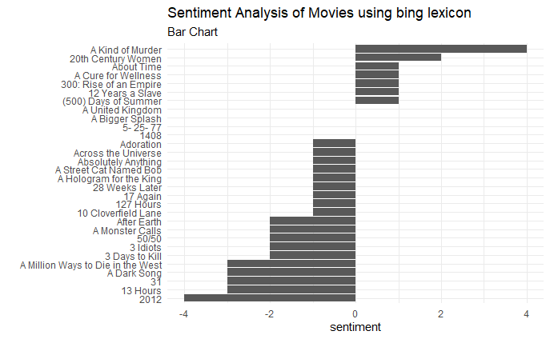

```r
bing_chart<-movie_stop_rem %>%
  inner_join(get_sentiments("bing")) %>%
  count(Title, sentiment) %>%
  spread(sentiment, n, fill = 0) %>%
  mutate(sentiment = positive - negative) %>%
  head(30) %>%
  ggplot() +
  geom_bar(aes(x = reorder(Title, sentiment),
               y = sentiment),
           stat = "identity") +
  coord_flip() +
  labs(x = "",
       title = "Sentiment Analysis of Movies using bing lexicon",
       subtitle = "Bar Chart") +
  theme_minimal()
bing_chart
```

The lexicon, **bing**, scores a term `sentiment` as either `positive` or `negative`. The table, `bing_movie`, is a modified table of `movie_stop_rem` with 3 added `Sentiment` columns: `negative`, `positive`, and `sentiment` (difference between positive and negative ).

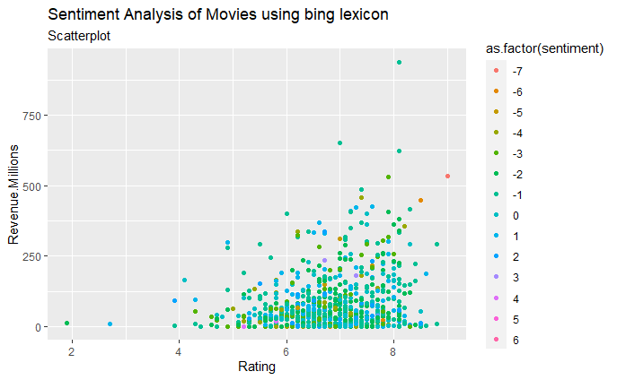

```r
bing_movie_scatter<-movie_stop_rem %>%
  inner_join(get_sentiments("bing")) %>%
  count(Title,Rating, Revenue.Millions, sentiment) %>%
  spread(sentiment, n, fill = 0) %>%
  mutate(sentiment = positive - negative) %>%
  ggplot(aes(x = Rating, y = Revenue.Millions, color = as.factor(sentiment)))+
  labs(title = "Sentiment Analysis of Movies using bing lexicon",
       subtitle = "Scatterplot") +
  geom_point()
bing_movie_scatter
```

The scatterplot above illustrates the movie terms’ relations between `Revenue (Millions)` and `Rating` which is clustered by the `bing` sentiment.

According to the graph, a majority of movie terms are from a movie with a `Rating` of around 4 to 9 and some outliers with a `Rating` of around 2 to 3. Most movie terms are from a movie with a `Revenue` of around 0 to 500 million dollars and some outliers with a `Revenue` of around 500 to 900 million dollars.

Most films are described in a mostly negative `bing sentiment` range of -4 to 2. Most highly rated and profitable movies are described in a negative `bing sentiment` of around -1 to -3.

Even though the graph has given good data for analysis, it lacks specification and precision since the plots and colors are too blended to differentiate between the other plots. The next few scatterplots will separate the `negative`, `positive`, and `neutral sentiments` with the last scatterplot re-categorizing the `sentiments` as either `positive`, `negative`, or `neutral`.

```r
#Positive and Neutral Sentiment Scatter Plot
pos_neu_movie_bing_scatter<-movie_stop_rem %>%
  inner_join(get_sentiments("bing")) %>%
  count(Title,Rating, Revenue.Millions, sentiment) %>%
  spread(sentiment, n, fill = 0) %>%
  mutate(sentiment = positive - negative) %>%
  filter(sentiment==c(0,1,2,3,4,5,6)) %>%
  ggplot(aes(x = Rating, y = Revenue.Millions, color = as.factor(sentiment)))+
  labs(title = "Positive and Neutral Sentiment Analysis of Movies using bing lexicon",
       subtitle = "Scatterplot") +
  geom_point()
```

```
longer object length is not a multiple of shorter object length
```

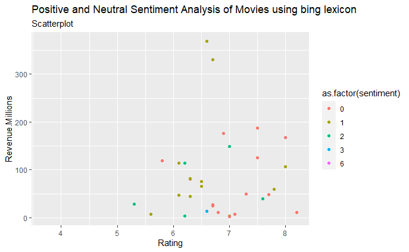

```r
pos_neu_movie_bing_scatter
```

The scatterplot above shows the plots in relation to `Rating` and `Revenue` with clusters of positive (1 to 6) and neutral (0) `bing sentiment`. The graph doesn’t seem to have a significant shape to make an inference.

For `bing sentiment` value of 0, it has a `Rating` range of ~5.7 to ~8.2 and a `Revenue` range of ~0 to ~190 million dollars. For `bing sentiment` value of 1, it has a `Rating` range of ~5.6 to ~8 and a `Revenue` range of ~0 to ~110 million dollars with outliers with a Revenue of ~320 and ~360 million. For `bing sentiment` value of 2, it has a `Rating` range of ~5.3 to ~7.6 and a `Revenue` range of ~0 to ~150 million dollars. For `bing sentiment` value of 3, has only one plot with a `Rating` value of ~6.6 and `Revenue` value of ~10 million dollars.

```r
#Negative Sentiment Scatter Plot
neg_movie_bing_scatter<-movie_stop_rem %>%
  inner_join(get_sentiments("bing")) %>%
  count(Title,Rating, Revenue.Millions, sentiment) %>%
  spread(sentiment, n, fill = 0) %>%
  mutate(sentiment = positive - negative) %>%
  filter(sentiment==c(-1,-2,-3,-4,-5,-6)) %>%
  ggplot(aes(x = Rating, y = Revenue.Millions, color = as.factor(sentiment)))+
  labs(title = "Negative Sentiment Analysis of Movies using bing lexicon",
       subtitle = "Scatterplot")+
  geom_point()
```

```
longer object length is not a multiple of shorter object length
```

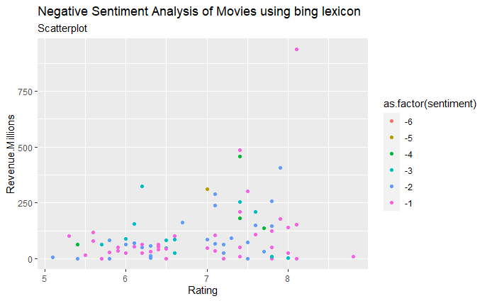

```r
neg_movie_bing_scatter
```

The scatterplot above shows the plots in relation to `Rating` and `Revenue` with clusters of negative (-6 to -1) `bing sentiment`. The `bing sentiments`, -1 and -2, have the highest `Revenue` and `Rating` in the `negative sentiment` scatterplot.

```r
cat_movie_bing<- movie_stop_rem %>%
  inner_join(get_sentiments("bing")) %>%
  count(Title,Rating, Revenue.Millions, sentiment) %>%
  spread(sentiment, n, fill = 0) %>%
  mutate(sentiment = positive - negative)
cat_movie_bing<-cat_movie_bing %>% mutate(Sentiment_Category = cut(sentiment,
                                      breaks = c(-7,-1,0,6),
                                      labels=c("Negative", "Neutral", "Positive")))
cat_movie_bing_scatter<-cat_movie_bing %>%
  ggplot(aes(x = Rating, y = Revenue.Millions, color = as.factor(Sentiment_Category)))+
  labs(title = "Categorical Sentiment Analysis of Movies using bing lexicon",
       subtitle = "Scatterplot")+
geom_point()

cat_movie_bing
```

| Title | Rating | Revenue.Millions | negative | positive | sentiment | Sentiment_Category |
| --- | --- | --- | --- | --- | --- | --- |
| (500) Days of Summer | 7.7 | 32.39 | 1 | 2 | 1 | Positive |
| 10 Cloverfield Lane | 7.2 | 71.90 | 1 | 0 | -1 | Negative |
| 12 Years a Slave | 8.1 | 56.67 | 0 | 1 | 1 | Positive |
| 127 Hours | 7.6 | 18.33 | 2 | 1 | -1 | Negative |
| 13 Hours | 7.3 | 52.82 | 3 | 0 | -3 | Negative |
| 1408 | 6.8 | 71.98 | 1 | 1 | 0 | Neutral |
| 17 Again | 6.4 | 64.15 | 1 | 0 | -1 | Negative |
| 2012 | 5.8 | 166.11 | 4 | 0 | -4 | Negative |
| 20th Century Women | 7.4 | 5.66 | 0 | 2 | 2 | Positive |
| 28 Weeks Later | 7.0 | 28.64 | 2 | 1 | -1 | Negative |

[output cut: 841 more lines]

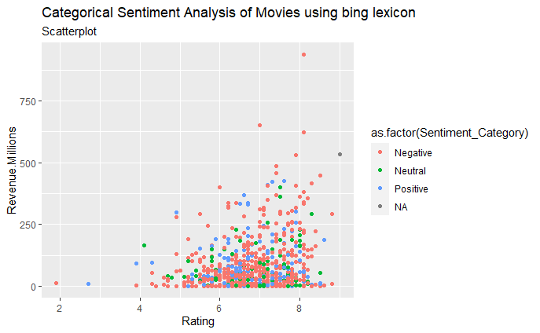

```r
cat_movie_bing_scatter
```

The graph is a categorical `bing sentimental` scatterplot that clusters the plots by `Sentinment_Category` with 3 categories: `Negative` (-6 to -1), `Neutral` (0), and `Positive` (1 to 6).

The scatterplot shows that the negative `bing sentiment` dominates more frequently than positive and neutral `bing sentiment`. Not to mention, that the negative `sentiment` is the most likely sentiment to have a high `Revenue` and `Rating`, which means that movie’s with a `negative bing sentiment` are more likely to be successful thatn those that have a `positive` or `neutral bing sentiment.`

### Sentiment Analysis of Movies using nrc lexicon

```r
nrc_movie<-movie_stop_rem %>%
  inner_join(get_sentiments("nrc")) %>%
  group_by(sentiment) %>%
  count(Title, Rating, Revenue.Millions, sentiment)
nrc_movie
```

| sentiment | Title | Rating | Revenue.Millions | n |
| --- | --- | --- | --- | --- |
| anger | 10 Cloverfield Lane | 7.2 | 71.90 | 1 |
| anger | 12 Years a Slave | 8.1 | 56.67 | 1 |
| anger | 13 Hours | 7.3 | 52.82 | 2 |
| anger | 17 Again | 6.4 | 64.15 | 1 |
| anger | 2012 | 5.8 | 166.11 | 2 |
| anger | 2307: Winter's Dream | 4.0 | 20.76 | 2 |
| anger | 28 Weeks Later | 7.0 | 28.64 | 1 |
| anger | 3 Days to Kill | 6.2 | 30.69 | 1 |
| anger | 300 | 7.7 | 210.59 | 2 |
| anger | 300: Rise of an Empire | 6.2 | 106.37 | 1 |

[output cut: 990 more lines]

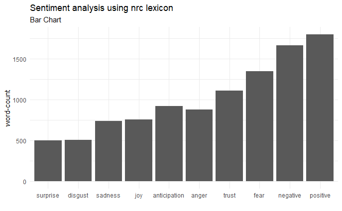

```r
nrc_bar<-movie_stop_rem %>%
  inner_join(get_sentiments("nrc")) %>%
  group_by(sentiment) %>%
  count(Title, Rating, Revenue.Millions, sentiment) %>%
  ggplot() +
  geom_bar(
    aes(x = reorder(sentiment, n),
        y = n),
    stat = "identity") +
  labs(title = "Sentiment analysis using nrc lexicon",
       subtitle = "Bar Chart",
       x = "",
       y = "word-count") +
  theme_minimal()
nrc_bar
```

The table above is a dataframe of `movie_stop_rem` with an inner join to the lexicon, `nrc`. The lexicon, **nrc**, categorizes a term under a `sentiment` type category: `positive`, `negative`, `anger`, `anticipation`, `disgust`, `fear`, `joy`, `sadness`, `surprise`, and `trust`. The table has a column called `n`, which is the word-count of the every `nrc sentiment` category.

The graph above is a bar chart from the dataframe, `nrc_movie`, which counts the word frequency of the `nrc sentiment` category. The highest frequented `nrc sentiment`, is `positive`, while the lowest frequented `nrc sentiment` is `surprise`.

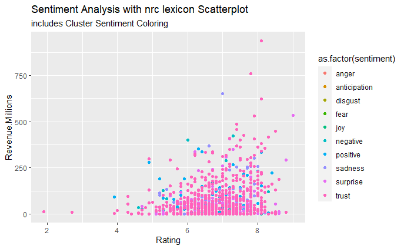

```r
movie_nrc<-movie_stop_rem %>%
  inner_join(get_sentiments("nrc")) %>%
  group_by(sentiment) %>%
  count(Title, Rating, Revenue.Millions, sentiment) %>%
  filter() %>%
  ggplot(aes(x = Rating, y = Revenue.Millions, color = as.factor(sentiment))) +
  geom_point() +
  labs(title = "Sentiment Analysis with nrc lexicon Scatterplot",
       subtitle = "includes Cluster Sentiment Coloring")
movie_nrc
```

```r
#sentiment=="surprise"
```

The scatterplot above shows the movie terms’ relations between Revenue (Millions) and Rating which is clustered by the `nrc` sentiment. Based on the visual, it seems that movie `Descriptions` are dominated by the `nrc sentiment` **surprise** and **trust**. These 2 categories are the most likely `nrc sentiment` to have a high `Revenue` and `Rating`.

This graph is too blended with the colors, since the color key for some of the `nrc sentiments` are similar. This project will divide the `nrc sentiments` to 3 categories: `positive` (`joy`, `anticipation`, `positive`, `truth`), `negative` (`anger`, `disgust`, `fear`, `negative`, `sadness`), and `neutral`(`surprise`). These categorical values were based on the `nrc` diagram in the webpage, [NRC Word-Emotion Association Lexicon](http://saifmohammad.com/WebPages/NRC-Emotion-Lexicon.htm).

```r
neg_movie_nrc_scatter<-movie_stop_rem %>%
  inner_join(get_sentiments("nrc")) %>%
  group_by(sentiment) %>%
  count(Title, Rating, Revenue.Millions, sentiment) %>%
  filter(sentiment==c("anger", "disgust", "fear", "negative", "sadness")) %>%
  ggplot(aes(x = Rating, y = Revenue.Millions, color = as.factor(sentiment))) +
  geom_point() +
  labs(title = "Negative Sentiment Analysis with nrc lexicon Scatterplot",
       subtitle = "includes Cluster Sentiment Coloring")
```

[output not shown]

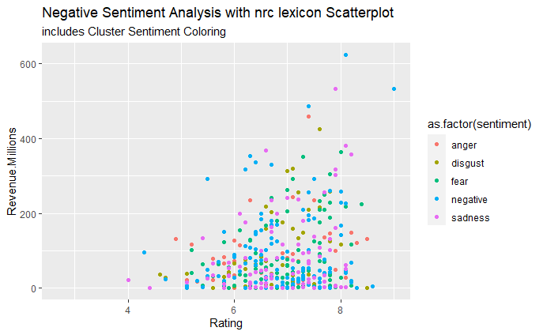

```r
neg_movie_nrc_scatter
```

```r
#sentiment=="surprise"
#shape=1
```

The scatterplot shown above is in regard to `negative nrc sentiments` with 5 categories: `anger`, `disgust`, `fear`, `negative`, and `sadness`.

The graph is being dominated by the `negative sentiments`, `negative` and `sadness`, which show that that the most highly rated and highly profitable movies that have `negative sentiment` descriptions have terms related to having `nrc` lexicons called `negative` and `sadness`. Also, the plots are accumulating in the `Rating` range of ~4 to ~9 with a `Revenue` range of ~0 to ~550 million with an outlier of ~620 million.

[output not shown]

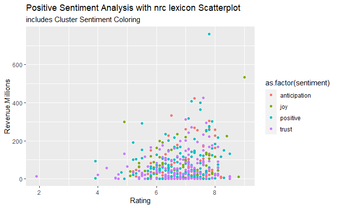

```r
movie_stop_rem %>%
  inner_join(get_sentiments("nrc")) %>%
  group_by(sentiment) %>%
  count(Title, Rating, Revenue.Millions, sentiment) %>%
  filter(sentiment==c("joy", "positive", "anticipation", "trust")) %>%
  ggplot(aes(x = Rating, y = Revenue.Millions, color = as.factor(sentiment))) +
  geom_point()+
  labs(title = "Positive Sentiment Analysis with nrc lexicon Scatterplot",
       subtitle = "includes Cluster Sentiment Coloring")
```

The scatterplot shown above is in regard to `positive nrc sentiments` with 4 categories: `anticipation`, `joy`, `positive`, and `trust`.

The graph is only concentrated by the `positive sentiments`, `trust` and `positive`, which shows that that the most highly rated and highly profitable movies that have `positive sentiment` descriptions have terms related to having `nrc` lexicons called `positive` and `trust`.

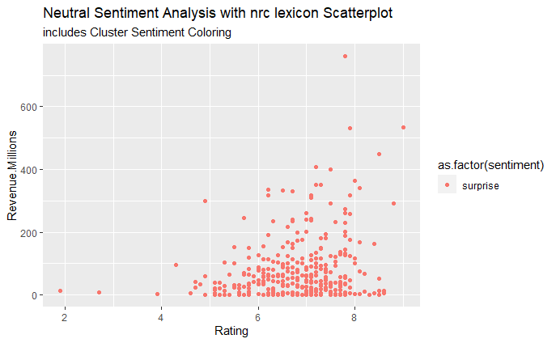

```r
movie_stop_rem %>%
  inner_join(get_sentiments("nrc")) %>%
  group_by(sentiment) %>%
  count(Title, Rating, Revenue.Millions, sentiment) %>%
  filter(sentiment==c("surprise")) %>%
  ggplot(aes(x = Rating, y = Revenue.Millions, color = as.factor(sentiment))) +
  geom_point() +
  labs(title = "Neutral Sentiment Analysis with nrc lexicon Scatterplot",
       subtitle = "includes Cluster Sentiment Coloring")
```

```r
NA
```

The scatterplot shown above is excludes `positive and negative nrc sentiments` with 1 category: `surprise`, since it’s the only category that wasn’t place as `positive` or `negative` in the article, [NRC Word-Emotion Association Lexicon](http://saifmohammad.com/WebPages/NRC-Emotion-Lexicon.htm).

The graph is only concentrated by the `neutral sentiment`, `surprise`, which shows that it has a `Rating` range of ~5 to ~9 with some outliers, and a `Revenue` range of ~0 to ~400 million with some outliers.

```r
cat_movie_nrc<- movie_stop_rem %>%
  inner_join(get_sentiments("nrc")) %>%
  group_by(sentiment) %>%
  count(Title, Rating, Revenue.Millions, sentiment)
cat_movie_nrc$Sentiment_Category[cat_movie_nrc$sentiment == "joy" | cat_movie_nrc$sentiment =="positive"| cat_movie_nrc$sentiment == "trust"| cat_movie_nrc$sentiment == "anticipation" ] = "Positive"
```

```
Unknown or uninitialised column: `Sentiment_Category`.
```

```r
cat_movie_nrc$Sentiment_Category[ cat_movie_nrc$sentiment == "surprise"] = "Neutral"

cat_movie_nrc$Sentiment_Category[cat_movie_nrc$sentiment == "anger" | cat_movie_nrc$sentiment == "disgust"| cat_movie_nrc$sentiment == "fear" | cat_movie_nrc$sentiment == "negative" | cat_movie_nrc$sentiment == "sadness"] = "Negative"

cat_movie_nrc
```

| sentiment | Title | Rating | Revenue.Millions | n | Sentiment_Category |
| --- | --- | --- | --- | --- | --- |
| anger | 10 Cloverfield Lane | 7.2 | 71.90 | 1 | Negative |
| anger | 12 Years a Slave | 8.1 | 56.67 | 1 | Negative |
| anger | 13 Hours | 7.3 | 52.82 | 2 | Negative |
| anger | 17 Again | 6.4 | 64.15 | 1 | Negative |
| anger | 2012 | 5.8 | 166.11 | 2 | Negative |
| anger | 2307: Winter's Dream | 4.0 | 20.76 | 2 | Negative |
| anger | 28 Weeks Later | 7.0 | 28.64 | 1 | Negative |
| anger | 3 Days to Kill | 6.2 | 30.69 | 1 | Negative |
| anger | 300 | 7.7 | 210.59 | 2 | Negative |
| anger | 300: Rise of an Empire | 6.2 | 106.37 | 1 | Negative |

[output cut: 990 more lines]

```r
cat_movie_nrc_scatter<-cat_movie_nrc %>%
  ggplot(aes(x = Rating, y = Revenue.Millions, color = as.factor(Sentiment_Category)))+
  labs(title = "Categorical Sentiment Analysis of Movies using nrc lexicon",
       subtitle = "Scatterplot")+
  geom_point(shape=1)
cat_movie_nrc
```

| sentiment | Title | Rating | Revenue.Millions | n | Sentiment_Category |
| --- | --- | --- | --- | --- | --- |
| anger | 10 Cloverfield Lane | 7.2 | 71.90 | 1 | Negative |
| anger | 12 Years a Slave | 8.1 | 56.67 | 1 | Negative |
| anger | 13 Hours | 7.3 | 52.82 | 2 | Negative |
| anger | 17 Again | 6.4 | 64.15 | 1 | Negative |
| anger | 2012 | 5.8 | 166.11 | 2 | Negative |
| anger | 2307: Winter's Dream | 4.0 | 20.76 | 2 | Negative |
| anger | 28 Weeks Later | 7.0 | 28.64 | 1 | Negative |
| anger | 3 Days to Kill | 6.2 | 30.69 | 1 | Negative |
| anger | 300 | 7.7 | 210.59 | 2 | Negative |
| anger | 300: Rise of an Empire | 6.2 | 106.37 | 1 | Negative |

[output cut: 990 more lines]

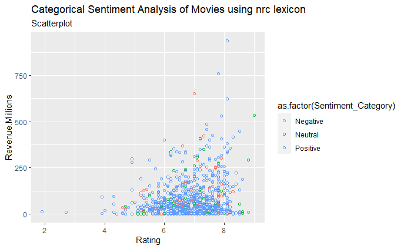

```r
cat_movie_nrc_scatter
```

The graph is a categorical `nrc sentimental` scatterplot that clusters the plots by `Sentinment_Category` with 3 categories: `Negative` (`anger`, `disgust`, `fear`, `negative`, `sadness`), `Neutral` (`Surprise`), and `Positive` (`joy`, `anticipation`, `positive`, `truth`).

The scatterplot shows that the positive `nrc sentiment` is more frequent than negative and neutral `nrc sentiment`. Not to mention, that the positive `sentiment` is the most likely sentiment to have a high `Revenue` and `Rating`.

The `nrc` scatterplot has a different `sentiment` result than the `bing` scatterplot, where the `bing` scatterplot is more dominated by the `negative sentiment`. Based on the article, [Sentiment analysis with tidy data](https://www.tidytextmining.com/sentiment.html), the reason for this to occur is that the “ratio of negative to positive words is higher in the `bing` lexicon than the `nrc` lexicon”

# Network of Bigrams for Movies

```r
movie_filtered <- movie_desc %>%
    unnest_tokens(bigram, Description, token = "ngrams", n = 2) %>%
    separate(bigram, into = c("word1", "word2"), sep = " ") %>%
    filter(!word1 %in% stop_words$word, !is.na(word1)) %>%
    filter(!word2 %in% stop_words$word, !is.na(word2))
movie_filtered
```

| Rank | Title | Runtime.Minutes | Rating | Votes | Revenue.Millions | Metascore | word1 | word2 |
| --- | --- | --- | --- | --- | --- | --- | --- | --- |
| 1 | Guardians of the Galaxy | 121 | 8.1 | 757074 | 333.13 | 76 | intergalactic | criminals |
| 1 | Guardians of the Galaxy | 121 | 8.1 | 757074 | 333.13 | 76 | fanatical | warrior |
| 1 | Guardians of the Galaxy | 121 | 8.1 | 757074 | 333.13 | 76 | taking | control |
| 2 | Prometheus | 124 | 7.0 | 485820 | 126.46 | 65 | distant | moon |
| 3 | Split | 117 | 7.3 | 157606 | 138.12 | 62 | diagnosed | 23 |
| 3 | Split | 117 | 7.3 | 157606 | 138.12 | 62 | 23 | distinct |
| 3 | Split | 117 | 7.3 | 157606 | 138.12 | 62 | distinct | personalities |
| 3 | Split | 117 | 7.3 | 157606 | 138.12 | 62 | apparent | emergence |
| 4 | Sing | 108 | 7.2 | 60545 | 270.32 | 59 | humanoid | animals |
| 4 | Sing | 108 | 7.2 | 60545 | 270.32 | 59 | hustling | theater |

[output cut: 990 more lines]

> Removes stop-words and performs tokenization on the dataframe, `movie_desc`

```r
movie_counts <- movie_filtered %>%
  count(word1, word2, sort = TRUE)
movie_counts
```

| word1 | word2 | n |
| --- | --- | --- |
| los | angeles | 16 |
| york | city | 9 |
| cia | agent | 8 |
| fbi | agent | 7 |
| true | story | 7 |
| world | war | 7 |
| war | ii | 6 |
| post | apocalyptic | 5 |
| seemingly | perfect | 5 |
| serial | killer | 5 |

[output cut: 990 more lines]

> The most common combinations of words in the Movie’s `Description`

```r
# filter for only relatively
# common combinations
bigram_graph <- movie_counts %>%
  filter(n > 3) %>%
  graph_from_data_frame()
bigram_graph
```

```
IGRAPH afd9b59 DN-- 38 21 --
+ attr: name (v/c), n (e/n)
+ edges from afd9b59 (vertex names):
 [1] los      ->angeles     york     ->city        cia      ->agent
 [4] fbi      ->agent       true     ->story       world    ->war
 [7] war      ->ii          post     ->apocalyptic seemingly->perfect
[10] serial   ->killer      true     ->love        19th     ->century
[13] african  ->american    arms     ->dealer      join     ->forces
[16] katniss  ->everdeen    perfect  ->life        police   ->officer
[19] single   ->mother      teenage  ->girl        twin     ->peaks
```

The `bigram_graph` builds the graph from the data frame, `movie_counts`, where the value of `n` is set to be greater than 3 in order to reduce complexity of the bigram diagram.

[figure not shown]

```r
set.seed(310)
# set arrow
a <- grid::arrow(
  type = "closed",
  length = unit(.10, "inches"))

# plot graph
ggraph(bigram_graph, layout = "fr") +
  geom_edge_link(
    aes(edge_alpha = n),
    show.legend = FALSE, arrow = a,
    end_cap = circle(.07, 'inches')) +
  geom_node_point(color = "#53316B",
                  size = 4) +
  geom_node_text(aes(label = name),
                 vjust = 1.5, hjust = 0.2) +
  theme_void()
```

# Conclusion

This project explored text mining techniques in order to develop relational analysis concerning movie `Description` terms from the dataset, `IMDB_movies.csv`.

Tokenization (TF-DF) was used to increase efficiency to analyze term frequencies in movie `Descriptions`, so that the conceptual theme of a movie franchise would be determined even if a person has never watched any of the films. This would be distinctly purposeful for those who are categorizing movies into genres in a streaming service company like *Netflix*. This could be further explored if a user also implements nonrelational and relational database to store these terms for future reference. Topic Modeling created mixtures of terms that are correlated to every topic and the mixture of topics that distinguishes each document in the dataset, `IMDB_movies.csv`.

Sentimental Analysis focused on movies with `Sentimetal` Clusters that were used `bing` and `nrc` lexicons to see how `Sentiment` affects `Rating` and `Revenue`. When trying to implement the `nrc` dataframe to re-organize the string categories into more general categories, it was a challenge to transform the data categories since it was initialized with string values, but eventually a solution was revealed and it helped greatly with the Sentimental Analysis. It is beneficial to re-categorize the `sentiment` categories from `nrc` and `bing` into a system with 3 categories: `Negative`, `Positive`, `Neutral`. This kind of system helped with Cluster Analysis in ggplot, since there was too many categories to analyze in one graph.

The network of bigrams for the movies dataset help summarize how frequented movie `Description` words create term relationships and how they connect to other movies. This type of text mining technique can be also used to see if the films who share similar text relations have similar storylines and genres.

The project has proven that text mining techniques can ease better analysis for categorizing movies with just the `Descriptions` while excluding the `Genre`from the dataset, `IMDB_movies.csv`.

# References

(n.d.). Retrieved from http://saifmohammad.com/WebPages/NRC-Emotion-Lexicon.htm

Robinson, J. S. A. D. (2020). 2 Sentiment analysis with tidy data | Text Mining with R. Titdy Text Mining. https://www.tidytextmining.com/sentiment.html